# HW3

Thomas Grover

2024-11-11

## Task 1: Prescriptive Part

### Programming Questions

Importing necessary packages and setting working directory.

```r
library(tidyverse)
```

```r
library(readxl)
library(ggplot2)
setwd('C:\\Users\\wic\\Documents\\ST 308')
```

Reading the data into the beans_data object using read_xslx, and printing some information about the data using inline code.

```r
beans_data <- read_xlsx("tmgrover_beans.xlsx")
```

The data has been read into the object beans_data. This object is a tbl_df that has 17 variables and 9527 observations.

Using tidyverse functions and chaining or piping to complete the desired manipulations to the data set. First using the select function to include all variables other than eccentricity and roundness, then using the rename function to shorten the names for the major and minor axis length variables. From here I used the filter function in combination with the %in% operator to only include observations in which the class variable was one of the ones in a specific list. Continuing, I use a mutate function to add the average length variable, as well as a new categorical variable that relates to aspect ratio. Finally, I finish by ordering the rows by convex area in descending order and calling my new object.

```r
new_beans_data <- beans_data %>%
  select(-Eccentricity, -Roundness) %>%
  rename(LengthMaj = MajorAxisLength, LengthMin = MinorAxisLength) %>%
  filter(Class %in% c("DERMASON", "SIRA", "CALI", "HOROZ", "BOMBAY")) %>%
  mutate(AvgLength = (LengthMaj + LengthMin) / 2,
         AspectRatioCategory = case_when(
           AspectRatio > 1.650262 ~ "Largest",
           AspectRatio > 1.513478 ~ "Medium",
           TRUE ~ "Lowest"
         )) %>%
  arrange(desc(ConvexArea))

new_beans_data
```

```
## # A tibble: 7,200 × 17
##      Area Perimeter LengthMaj LengthMin AspectRatio ConvexArea EquivDiameter
##     <dbl>     <dbl>     <dbl>     <dbl>       <dbl>      <dbl>         <dbl>
##  1 254616     1985.      739.      447.        1.65     263261          569.
##  2 241322     1896.      726.      427.        1.70     244319          554.
##  3 237270     1922.      738.      413.        1.79     240671          550.
##  4 234898     1870.      695.      433.        1.61     238265          547.
##  5 233751     1849.      707.      424.        1.67     237344          546.
##  6 230867     1815.      672.      441.        1.52     233243          542.
##  7 231066     1788.      642.      460.        1.39     232903          542.
##  8 226806     1813.      680.      429.        1.59     229994          537.
##  9 224267     1771.      640.      449.        1.43     226132          534.
## 10 223165     1828.      669.      428.        1.56     226058          533.
## # ℹ 7,190 more rows
## # ℹ 10 more variables: Extent <dbl>, Solidity <dbl>, Compactness <dbl>,
## #   ShapeFactor1 <dbl>, ShapeFactor2 <dbl>, ShapeFactor3 <dbl>,
## #   ShapeFactor4 <dbl>, Class <chr>, AvgLength <dbl>, AspectRatioCategory <chr>
```

Creating a correlation matrix of the desired variables using chaining and the `cor()` function. Then calling the object.

```r
cor_matrix <- new_beans_data %>%
  select(Area, Perimeter, AspectRatio, ConvexArea, EquivDiameter) %>%
  cor()
cor_matrix
```

```
##                    Area Perimeter AspectRatio ConvexArea EquivDiameter
## Area          1.0000000 0.9731257   0.2000080  0.9999489     0.9859821
## Perimeter     0.9731257 1.0000000   0.3698169  0.9736856     0.9945730
## AspectRatio   0.2000080 0.3698169   1.0000000  0.2014652     0.2861298
## ConvexArea    0.9999489 0.9736856   0.2014652  1.0000000     0.9861369
## EquivDiameter 0.9859821 0.9945730   0.2861298  0.9861369     1.0000000
```

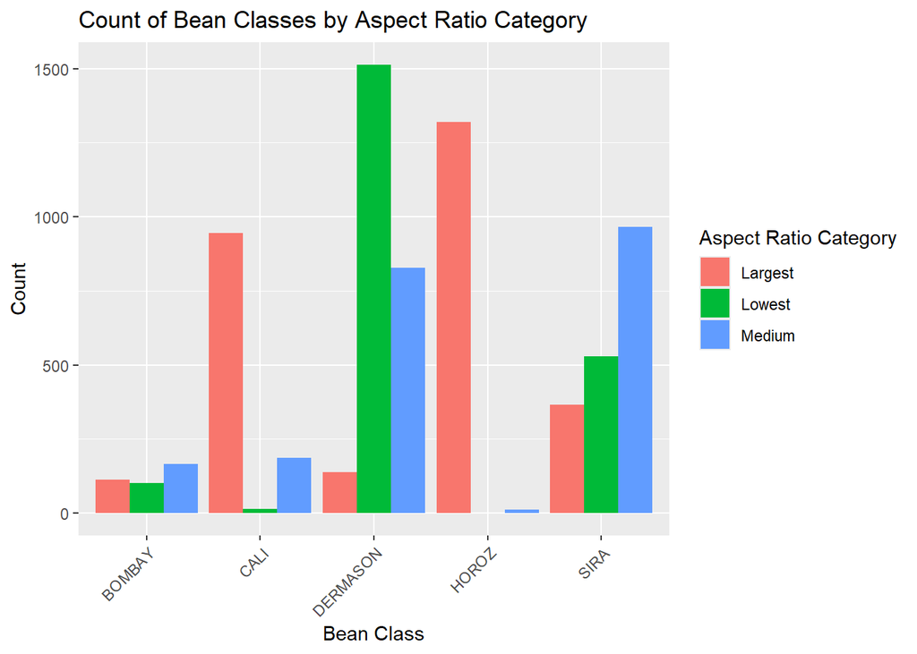

```r
ggplot(new_beans_data, aes(x = Class, fill = AspectRatioCategory)) +
  geom_bar(position = "dodge") +
  labs(title = "Count of Bean Classes by Aspect Ratio Category",
       x = "Bean Class",
       y = "Count",
       fill = "Aspect Ratio Category") +
  theme(axis.text.x = element_text(angle = 45, hjust = 1))
```

Next I will create a histogram of the extent variable, and use the `geom_density()` function in cooperation with the + operator to overlay a density plot over the histogram. Again the `labs()` function takes care of the title.

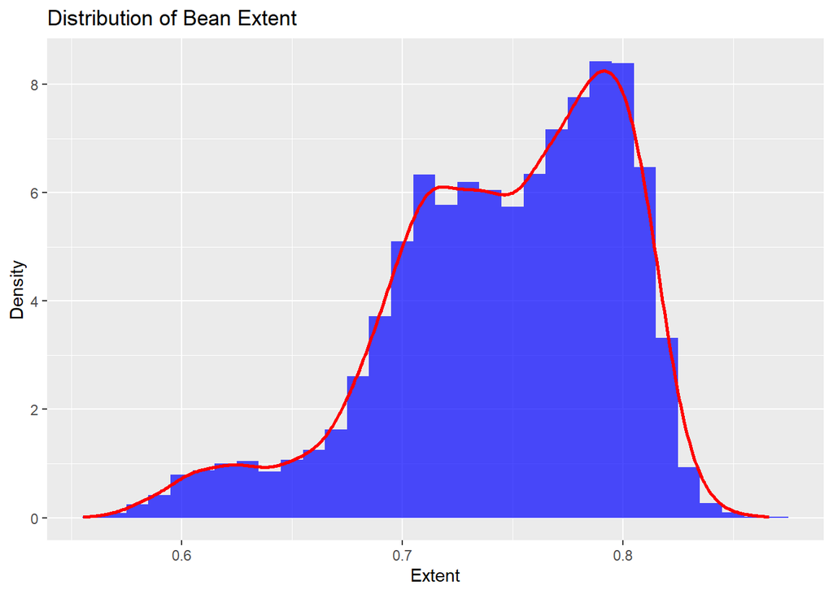

```r
ggplot(new_beans_data, aes(x = Extent)) +
  geom_histogram(aes(y = after_stat(density)), binwidth = 0.01, fill = "blue", alpha = 0.7) +
  geom_density(color = "red", linewidth = 1) +
  labs(title = "Distribution of Bean Extent",
       x = "Extent",
       y = "Density")
```

Lastly for the prescriptive part of the assignment, I am basically doing what I did above but for each unique class of bean. The main difference is the use of faceting, which is one of the most recent topics we covered. The `facet_wrap` function lets us specify that we are making a plot for each class, and also that the y is free to take values that “make sense” if you will. This is why the different plots have different maximums on the y-axis.

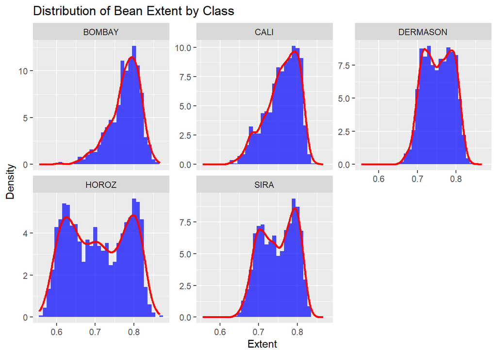

```r
ggplot(new_beans_data, aes(x = Extent)) +
  geom_histogram(aes(y = after_stat(density)), binwidth = 0.01, fill = "blue", alpha = 0.7) +
  geom_density(color = "red", linewidth = 1) +
  facet_wrap(~ Class, scales = "free_y") +
  labs(title = "Distribution of Bean Extent by Class",
       x = "Extent",
       y = "Density")
```

## Task 2: Open-Ended Part

The data set I will be using has variables about different wines. I found it at this link “https://archive.ics.uci.edu/dataset/186/wine+quality” and it is of interest because for one I don’t really know much about what separates different wines, and for two it was one of the first ones on the website to actually catch my eye. It actually is cool though how the different chemical properties of wine can play a role in the quality and flavor of it. It kind of reminds me of a scene in Breaking Bad where a chemist is trying to perfect coffee.

Reading in the data.

```r
wine_data <- read.csv("https://archive.ics.uci.edu/ml/machine-learning-databases/wine-quality/winequality-red.csv", sep=";")
```

#### Questions of Interest

1. Is there a relationship between pH and wine quality?
2. What is the spread of the quality variable?

Calculating pH summary statistics and using the cor function to check the linear relationship between pH and quality.

```r
ph_mean <- mean(wine_data$pH)
ph_variance <- var(wine_data$pH)
ph_sd <- sd(wine_data$pH)
ph_sample_size <- length(wine_data$pH)
cor(wine_data$pH, wine_data$quality, use = "complete.obs")
```

```
## [1] -0.05773139
```

Calculating quality summary statistics to look at the spread of the quality variable.

```r
quality_mean <- mean(wine_data$quality)
quality_median <- median(wine_data$quality)
quality_variance <- var(wine_data$quality)
quality_sd <- sd(wine_data$quality)
quality_sample_size <- length(wine_data$quality)
```

Creating a histogram to look at the distribution of quality.

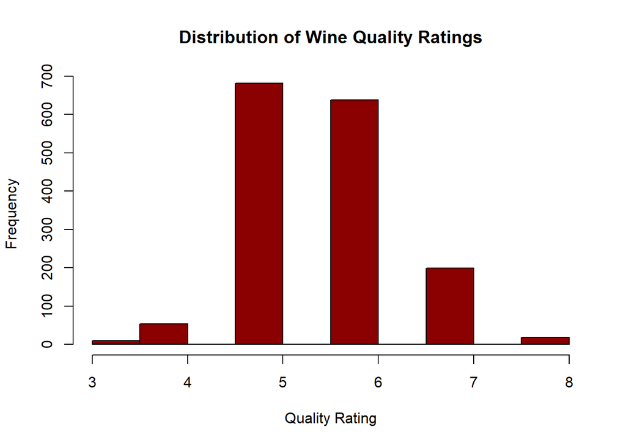

```r
quality_var <- var(wine_data$quality)
quality_sd <- sd(wine_data$quality)
hist(wine_data$quality, main="Distribution of Wine Quality Ratings",
     xlab="Quality Rating", ylab="Frequency", col="darkred", border="black")
```

In the histogram of the quality of wines, we can see how heavily concentrated the “average” wines if you will are. The 5 and 6 quality rankings are far and a way higher than the others, which is interesting but makes sense based on what we know about statistics and distributions. This is backed up with the values of the variance and standard deviation, being 0.6521684 and 0.8075694 respectively.

Creating a scatter plot to try and see any correlations between pH and wine quality.

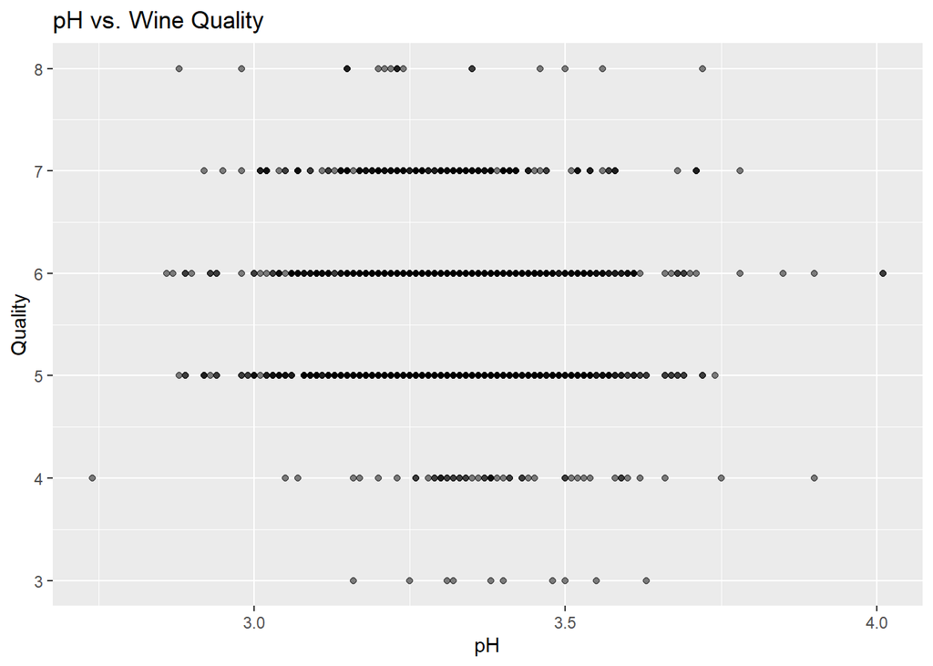

```r
ggplot(wine_data, aes(x = pH, y = quality)) +
  geom_point(alpha = 0.5) +
  labs(title = "pH vs. Wine Quality",
       x = "pH",
       y = "Quality")
```